# Week 2 Homework

Author

Mark Scott

# Setup

First we need to load our libraries. Personally, for network analysis I prefer `network` and `sna`.But I have of course used other packages, so no sweat. And I really do love network analysis; in my opinion it is one of the most versatile and interesting fields of statistics.

```r
set.seed(555)


# Load in libs
## Not necessary, but I like how clean it
libs = c("igraph","ggplot2","ggraph","rio"
         ,"tidyverse" #loading since I use some dplyr functions a few times
         )
invisible(suppressPackageStartupMessages(lapply(libs, library, character.only = TRUE)))
```

Now let us load in the data.

```r
URL = 'https://github.com/MarkGScott960/DACCS690C_HW2/raw/main/hollywood.graphml'
actorsnet = read_graph(URL, format = 'graphml')
summary(actorsnet) # what is the structure of the network
```

```
IGRAPH 50d8ef3 UNW- 11 14 --
+ attr: wonOscar (v/n), color (v/c), name (v/c), id (v/c), weight (e/n)
```

# Node centrality Measures

As you showed in the videos and HTML file, I will get the three centrality measures and put them in one nice `kable` table. I will also disregard the weights, otherwise `igraph` treats it as distances/costs, but the weight is number of collaborations. Of course, an argument can be made that the weights should be included in the eigenvector measure because `igraph` treats weights as connection strength; the weights are left out in the `eigen_centrality()` function because I am comparing all three measures.

```r
# Eigenvector Centrality
eigenv = eigen_centrality(actorsnet, weights = NA)$vector

#Closeness
nodeclose = closeness(actorsnet, normalized = T,weights = NA)

# Betweenness
betw = betweenness(actorsnet, normalized = T,weights = NA)

# Create dataframe
CentralityDF = tibble(
  Actor = names(eigenv),
  Eigenvector = eigenv,
  Closeness = nodeclose,
  Betweenness = betw)


# Kable table (and round the measures)
CentralityDF |>
  mutate(across(where(is.numeric), ~round(.,4))) |>
  kableExtra::kable()
```

| Actor | Eigenvector | Closeness | Betweenness |
| --- | --- | --- | --- |
| Robin Williams | 0.2151 | 0.3571 | 0.3556 |
| Tom Hardy | 0.6009 | 0.3704 | 0.0111 |
| Dustin Hoffman | 0.8878 | 0.4545 | 0.1778 |
| Leonardo DiCaprio | 1.0000 | 0.4762 | 0.3333 |
| Tom Hanks | 0.8037 | 0.5000 | 0.5333 |
| Al Pacino | 0.1194 | 0.2778 | 0.0000 |
| Morgan Freeman | 0.4256 | 0.3125 | 0.0222 |
| Robert De Niro | 0.1194 | 0.2778 | 0.0000 |
| Matt Damon | 0.3637 | 0.4348 | 0.4667 |
| Jack Nicholson | 0.5089 | 0.3704 | 0.0778 |
| Christian Bale | 0.6834 | 0.3846 | 0.1111 |

## Correlation plot

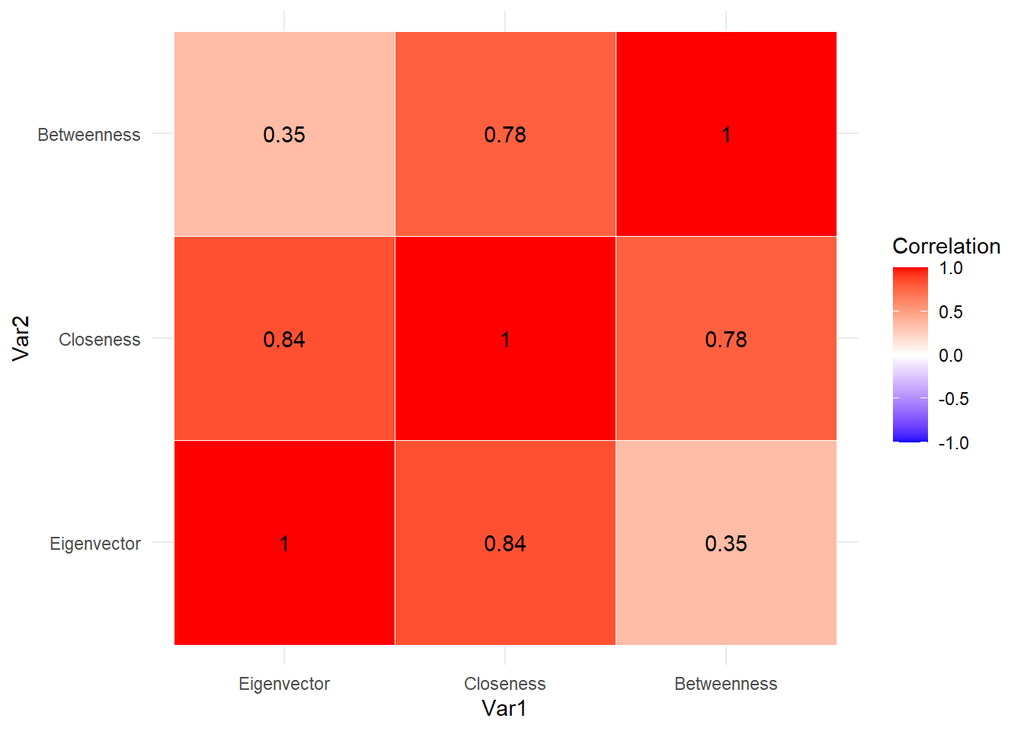

```r
#Calculate correlation
cormat = CentralityDF |>
  select(Eigenvector, Closeness, Betweenness) |>
  cor()

# make tidy and wide
corlong = as.data.frame(as.table(cormat))
colnames(corlong) <- c("Var1", "Var2", "Correlation")

#Plot
ggplot(corlong, aes(x = Var1, y = Var2, fill = Correlation)) +
  geom_tile(color = "white") +
  geom_text(aes(label = round(Correlation, 2))) +
  scale_fill_gradient2(
    low = "blue",
    mid = "white",
    high = "red",
    midpoint = 0,
    limits = c(-1, 1)
  ) +
  theme_minimal()
```

Now for some quick interpretation of this correlation heatmap:

| Pair | Correlation | Interpretation | Take away |
| --- | --- | --- | --- |
| **Closeness vs Betweenness** | **0.78** | Strong positive relationship | Actors who are closer to everyone else in the network also tend to lie on many of the shortest paths between other actors. |
| **Eigenvector vs Closeness** | **0.84** | Strong positive relationship | Actors with high eigenvector centrality have higher closeness. In other words, you can have very influential neighbors which leads to being close to everyone else. |
| **Eigenvector vs Betweenness** | **0.35** | Weak positive relationship | An actor connected to influential actors does not necessarily serve as a bridge between different parts of the network. |

Overall, we see that all three of our measures of node centrality are positively correlated. The two strongest correlations are between Eigenvector/closeness, and closeness/betweenness. This does, of course make sense. If an ego knew someone who know many people who knew many people, I would have a reasonably larger network because of the increased alter-to-alter ties.

Of course, our dataset has a highly restrictive sample size, so we should not be stating these as facts.

# Hub nodes plot

First lets see how many people are notable:

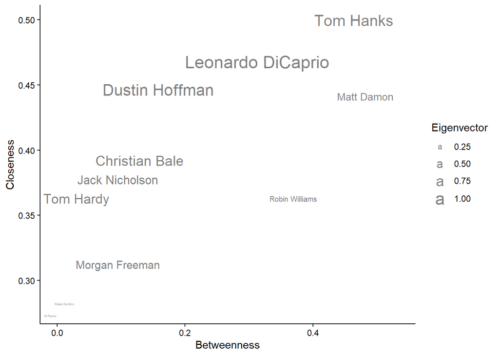

```r
ggplot(CentralityDF, aes(x=Betweenness, y=Closeness)) +
    theme_classic() +
  ggrepel::geom_text_repel(aes(label=Actor,size=Eigenvector),show.legend = T,alpha=0.5) # using this instead of geom_text for readability
```

```r
  #geom_text(aes(label=Actor,size=Eigenvector),show.legend = T,alpha=0.5)
```

```
Using "stress" as default layout
```

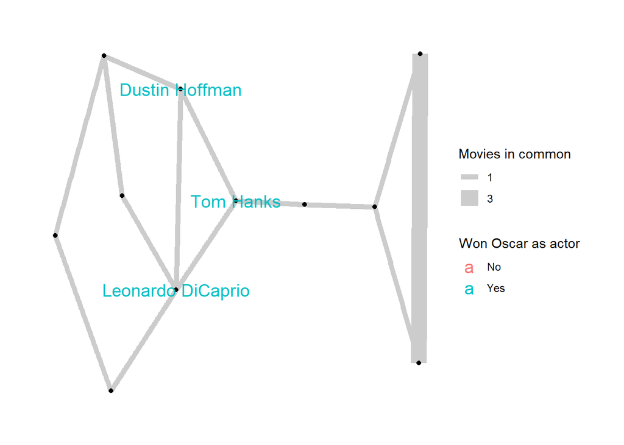

```r
#Define cutoff for who we consider important (will filter based on eigenvector score)
ImportantCut <-  0.8

# Get names of the important ones
HubNodes = CentralityDF |> filter(Eigenvector >= ImportantCut)


HubNodes  <- HubNodes$Actor



V(actorsnet)$label <- ifelse(
  V(actorsnet)$name %in% HubNodes,
  V(actorsnet)$name,
  ""
)


#Relabel attributes for easier reading
V(actorsnet)$wonOscar=ifelse(V(actorsnet)$wonOscar==1,'Yes','No')

#plot
ggraph(actorsnet) +
  geom_edge_link(aes(edge_width = as.ordered(weight)), color = 'grey80') + #added in the collaborations attribute frmn the final plot in example
  geom_node_point() +
  theme_graph(base_family = "sans") + #using sans otherwise getting a wall of warnings (default arial was not playing nice with my OS)
  geom_node_text(aes(label = label, color = as.factor(wonOscar)), size = 5)+ # added in the Oscar (0/1) attribute frmn the final plot in example
  labs(edge_width = "Movies in common", color = "Won Oscar as actor")
```

# Communities investigation

First lets start looking if communities may be present. From my understanding `sna` offers a rather extensive set of simulation functions for social network analysis. But as you showed, I use the `igraph` route.

```r
set.seed(555)

# Random Transitivity
repn = 1000

randomtransit <-  replicate(repn, {
  RandNet <- rewire(actorsnet,
                      keeping_degseq(niter = gsize(actorsnet) * 10))
  transitivity(RandNet, type = "global")
})
meanRandTransit = mean(randomtransit)


# Empirical Transitivity
emptransit <- transitivity(actorsnet, type = "global")

# Ratio
ComTest <- tibble(
  Metric = c("actorsnet transitivity", "randomnetwork mean", "Ratio"),
  Value = round(c(
    emptransit,
    meanRandTransit,
    emptransit / meanRandTransit),5)
  )
ComTest|>
  knitr::kable()
```

| Metric | Value |
| --- | --- |
| actorsnet transitivity | 0.25000 |
| randomnetwork mean | 0.12600 |
| Ratio | 1.98413 |

```r
# Some quick test
z_score <- (emptransit - mean(randomtransit)) / sd(randomtransit)
p_value <- sum(randomtransit >= emptransit) / repn #crude, but ~works

print(z_score)
```

```
[1] 1.158932
```

```r
print(p_value)
```

```
[1] 0.267
```

As a general rule, if we see a ratio over 1 we can expect standard algorithms to detect communities, which we do indeed see (ratio = 1.98413). However, with only 11 nodes and 14 edges, the null distribution is extremely noisy, so a p = 0.267 means that we cannot rule out that this clustering arose out of chance. I will still proceed to community detection as communities may be present, but our data cannot provide statistically significant evidence.

## Community Detection

```r
#get algorithms and values
algs <- list(
  louvain = {set.seed(555); cluster_louvain(actorsnet)},
  Girvan_Newman = cluster_edge_betweenness(actorsnet)
)
# Table it
sumtab <- data.frame(
  algorithm = names(algs),
  n_clusters = sapply(algs, length),
  modularity_Q = sapply(algs, modularity),
  cluster_sizes = sapply(algs, function(cl) {
    paste(sort(sizes(cl), decreasing = TRUE), collapse = ", ")})
)

# Sort then print
sumtab <- sumtab[order(-sumtab$modularity_Q), ]
rownames(sumtab) <- NULL

kableExtra::kable(sumtab)
```

| algorithm | n_clusters | modularity_Q | cluster_sizes |
| --- | --- | --- | --- |
| Girvan_Newman | 2 | 0.4199219 | 7, 4 |
| louvain | 3 | 0.4121094 | 4, 4, 3 |

According to our results, the Girvan-Newman algorithm is slightly better with a higher modularity.

### Plot of Best Result

```
Using "stress" as default layout
```

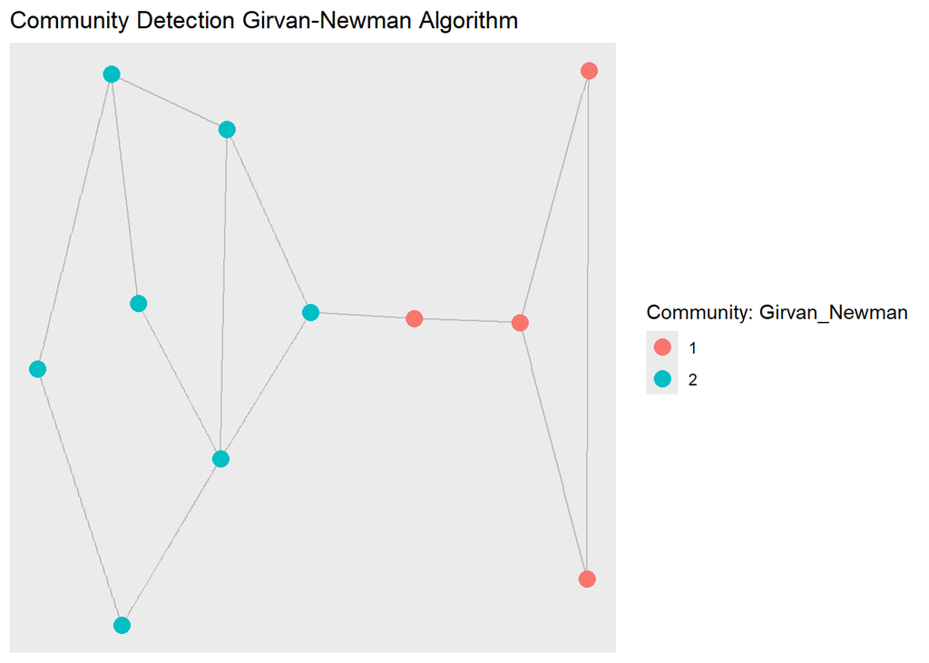

```r
for (name in names(algs)) {
  memb <- membership(algs[[name]])
  attr_name <- name
  actorsnet <- set_vertex_attr(actorsnet, attr_name,
                               index = names(memb),
                               value = as.vector(memb))
}

bestAlg <-  sumtab$algorithm[1]

ggraph(actorsnet) +
          geom_edge_link(alpha=0.2)+
  geom_node_point(aes(color=as.factor(.data[[bestAlg]])), show.legend = T, size=4)+
    labs(color = paste("Community:", bestAlg),
         title =paste("Community Detection",
                      sub("_","-",bestAlg), #fixes the underscore in Girvan-Newman
                      "Algorithm"))
```